# Reproducible Research_Gender Bias in Employment Decision Making

Dat Ngo

5/25/2021

## 1. Introduction

Reducing gender bias at work critical to nurture and motivate a healthy and dynamic workplace. There are many papers that research the effects and mechanism of this bias. In this paper, we reproduced the meta-analysis **“A Meta-Analysis of Gender Stereotypes and Bias in Experimental Simulations of Employment Decision Making”, Amanda J. Koch and Susan D. D’Mello, 2015**. The purpose of the reproducing paper is to understand this type of bias and verify whether the meta-analysis’s findings are still effective.

In this paper, we collected 5 other papers about gender bias in employment decision, calculated Cohen’s d values and combine with re-coding values from 10 papers from 136 samples in the meta-analysis to identify effect sizes.

## 2. Hypothesis

The original meta-analysis tested 6 hypothesis. However, in the scope of the project, we tested 2 hypothesis as below:

- Hypothesis 1. Gender-role congruity bias will be found, with men being rated more favorably than women for male-dominated jobs and women being rated more favorably than men for female-dominated jobs.
- Hypothesis 2. Male raters will exhibit stronger gender-role congruity bias than female raters.

## 3. Datasets and method

### 3.1. Datasets

Followings are criteria used to select papers in the original meta-analysis. We applied these criteria in searching additional papers:

- First, the studies had to be experimental. Most studies were simulations of employment contexts, with the typical paradigm being the evaluation of résumés that were identical or very similar other than the gender of the applicants.
- Second, studies had to include job-related ratings about a ratee (e.g., hireability, salary, competence, promotion).
- Third, studies had to provide enough data to allow for the computation of Cohen’s d (e.g., means, standard deviations, and sample sizes for repeated-measures or independent groups designs; correlations or t values for independent group designs).
- Fourth, studies were excluded if their samples consisted of participants from non-normal populations (e.g., prisoners).

### 3.2. Method

#### b. Coding

We followed the coding guidance from the original paper:

- Sex distribution within job: Each job used in a study was coded as male-dominated, female-dominated, or integrated based on the proportion of men and women who held that job in the country and during the time period in which the study was conducted.
- Rater gender: When possible, we coded d values for male and female rater groups. In cases where separate d values were not provided by rater gender, the sample was labeled as mixed/not specified and was not included in rater gender moderator analyses.
- Individuating information: The amount of individuating information was coded as the number of pieces of information provided to a decision maker, with the categories of pieces of information being résumé or job application, recommendation letter, videotape or transcript of interview, work sample or simulation, and performance appraisal.
- Type of evaluation: We coded two moderators related to the type of evaluation: type of comparison and type of employment rating. Type of comparison was coded as comparative or individual.Types of employment ratings were hiring, promotion, compensation, reward.
- Motivation to make careful decisions: We coded each study for contextual variables that would increase participants’ motivation to make careful decisions
- Type of participant: The type of participant was coded as undergraduate, working adult, or experienced professional. Experienced professional samples consisted of people with experience relevant to the decision-making task in the study.

## 4. Results and findings

### 4.1. Meta-analysis results

We calculated confidence interval of size effect and evaluate the random effects model using R’s meta library

```
##                                         MD             95%-CI %W(fixed)
## Hoover (2018), study 1             -0.0700 [-0.2633;  0.1233]      12.0
## Hoover (2018), study 2             -0.1300 [-0.3524;  0.0924]       9.1
## Rice (2015)                        -0.1300 [-0.3608;  0.1008]       8.4
## Rice (2016)                         0.2000 [ 0.0012;  0.3988]      11.4
## Soeter (2017)                      -0.1500 [-0.4703;  0.1703]       4.4
## Liberman & Okimoto (2008), Study 1 -0.0200 [-0.3587;  0.3187]       3.9
## Nicklin & Roch\n(2008)              0.0300 [-0.1230;  0.1830]      19.2
## Heilman & Haynes\n(2005), Study 1  -0.0900 [-0.5092;  0.3292]       2.6
## Heilman & Haynes\n(2005), Study 2  -0.3300 [-1.2117;  0.5517]       0.6
## Güngör & Biernat (2009)             0.7900 [ 0.3351;  1.2449]       2.2
## Castilla & Benard (2010)            0.0500 [-0.1829;  0.2829]       8.3
## Bruckmüller & Branscombe (2010)     0.4600 [ 0.1972;  0.7228]       6.5
## Bowles et al. (2007), Study 3      -0.7500 [-1.0536; -0.4464]       4.9
## Cunningham et al.(2010)             0.2700 [-0.1414;  0.6814]       2.7
## Hardin et al. (2002)                0.1000 [-0.2295;  0.4295]       4.1
##                                    %W(random)
## Hoover (2018), study 1                    8.3
## Hoover (2018), study 2                    7.9
## Rice (2015)                               7.8
## Rice (2016)                               8.2
## Soeter (2017)                             6.6
## Liberman & Okimoto (2008), Study 1        6.3
## Nicklin & Roch\n(2008)                    8.7
## Heilman & Haynes\n(2005), Study 1         5.4
## Heilman & Haynes\n(2005), Study 2         2.1
## Güngör & Biernat (2009)                   5.0
## Castilla & Benard (2010)                  7.7
## Bruckmüller & Branscombe (2010)           7.3
## Bowles et al. (2007), Study 3             6.8
## Cunningham et al.(2010)                   5.4
## Hardin et al. (2002)                      6.5
##
## Number of studies combined: k = 15
##
##                          MD            95%-CI    z p-value
## Fixed effect model   0.0117 [-0.0553; 0.0787] 0.34  0.7322
## Random effects model 0.0169 [-0.1280; 0.1619] 0.23  0.8189
##
## Quantifying heterogeneity:
##  tau^2 = 0.0564 [0.0271; 0.2218]; tau = 0.2376 [0.1648; 0.4710]
##  I^2 = 75.7% [59.8%; 85.2%]; H = 2.03 [1.58; 2.60]
##
## Test of heterogeneity:
##      Q d.f.  p-value
##  57.51   14 < 0.0001
##
## Details on meta-analytical method:
## - Inverse variance method
## - DerSimonian-Laird estimator for tau^2
## - Jackson method for confidence interval of tau^2 and tau
```

The output shows that our estimated effect is MD = 0.0169 with the 95% confidence interval stretches from -0.1280 to 0.1619. However, the p-value of random effects model is greater than 5%. **We cannot conclude a significant size effect of gender bias based on the selected researches.**

**Depicting size effects**

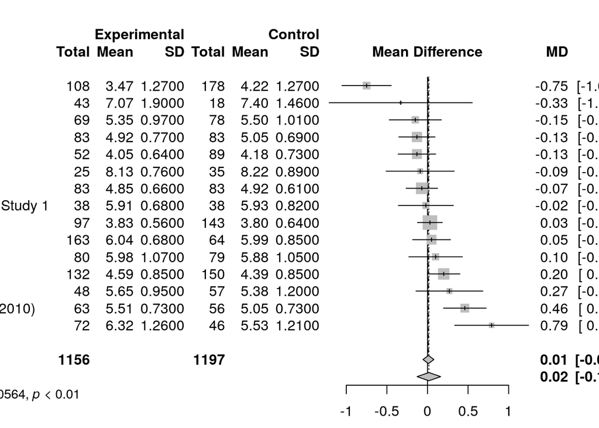

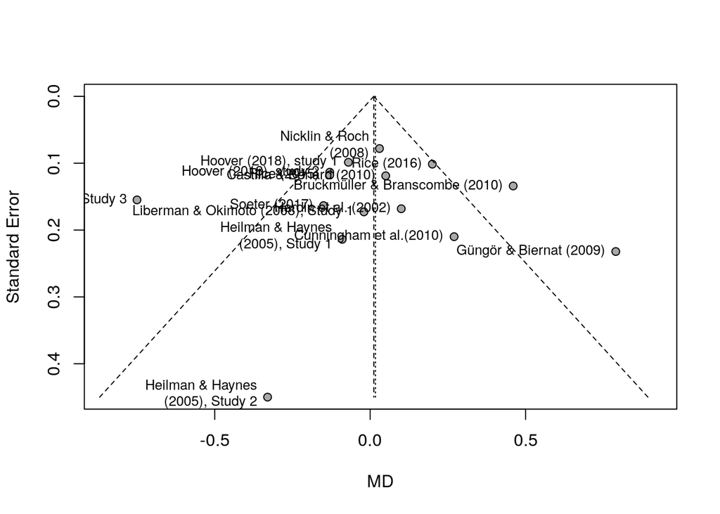

*In the funnel plot, selected samples are fairly symmetric, however, there are some samples out of the plot.*

### 4.2. Comparison to the original paper’s results

We calculated the weighted average size effect based on sample size to compare the project results with the original paper.

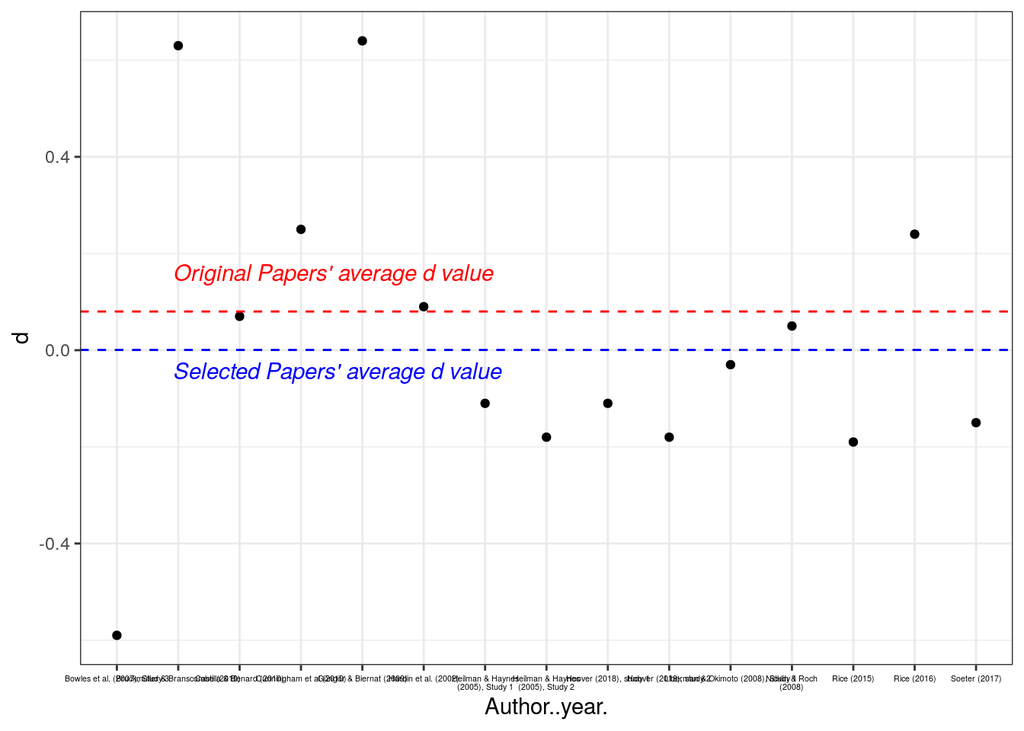

In general, the weighed average Cohen’s d value from selected papers was lower than the original one. This indicates a less gender bias random effects from selected papers compared to the original paper.

Besides, the weighed Cohen’s d value from selected paper was less than 0.2. This means there is a very small effect size from selected researches.

Size effects by Job type

| Sex.distribution | no_papers | total_sample | mean_d | SD | CI_90_percent_Lower | CI_90_percent_Upper |
| --- | --- | --- | --- | --- | --- | --- |
| Integrated | 11 | 1813 | -0.0899 | 0.2358 | -0.0990 | -0.0808 |
| Male-dominated | 4 | 542 | 0.3030 | 0.3574 | 0.2778 | 0.3283 |

We can see a Cohen’s d value greater than 0.2 in the group of paper researching male-dominated jobs. This is the same as the **Hypothesis 1** that men being rated more favorably than women for male-dominated jobs.

However, because of the lack in selected papers, we cannot see women being rated more favorably than men for female-dominated jobs.

Size effects by Rater Gender

| Rater.Gender | no_papers | total_sample | mean_d | SD | CI_90_percent_Lower | CI_90_percent_Upper |
| --- | --- | --- | --- | --- | --- | --- |
| Males | 2 | 332 | -0.1450 | 0.0495 | -0.1495 | -0.1405 |
| No | 11 | 1578 | 0.1291 | 0.3004 | 0.1167 | 0.1416 |
| Yes | 2 | 445 | -0.3470 | 0.4808 | -0.3845 | -0.3095 |

On the selected researches, male raters have a negative average d value, which means they rated female applicants higher than male applicants.

Due to the lack of paper whose raters are female, we cannot conclude the **Hypothesis 2** male raters are more gender-role congruity bias than women raters.

## 5. Conclusion

The result from project is not like the original paper due to the following reasons: - The small number of papers collected compared to the original one - The collected researches’ participants are different from the original one

To improve the quality of the meta-analysis, the team should investigate more researches related to gender bias not only in recruitment but also in person evaluation and promotion, penalty.

## Appendix 1: List of papers included in the meta-analysis

(papers we added have a star (*) before the reference)

Babcock, Linda, and Lei Lai. 2007. “Social Incentives for Gender Differences in the Propensity to Initiate Negotiations: Sometimes It Does Hurt to Ask.” *Organizational Behavior and Human Decision Processes*.

Bruckmüller, Susanne, and Nyla R Branscombe. 2010. “The Glass Cliff: When and Why Women Are Selected as Leaders in Crisis Contexts.” *British Journal of Social Psychology* 49 (3): 433–51.

Castilla, Emilio J, and Stephen Benard. 2010. “The Paradox of Meritocracy in Organizations.” *Administrative Science Quarterly* 55 (4): 543–676.

Cunningham, George B, Melanie L Sartore, and Brian P McCullough. 2010. “The Influence of Applicant Sexual Orientation, Applicant Gender, and Rater Gender on Ascribed Attributions and Hiring Recommendations of Personal Trainers.” *Journal of Sport Management* 24 (4): 400–415.

Güngör, Gökçe, and Monica Biernat. 2009. “Gender Bias or Motherhood Disadvantage? Judgments of Blue Collar Mothers and Fathers in the Workplace.” *Sex Roles* 60 (3): 232–46.

Hardin, J Russell, Kurt F Reding, and Morris H Stocks. 2002. “The Effect of Gender on the Recruitment of Entry-Level Accountants.” *Journal of Managerial Issues*, 251–66.

Heilman, Madeline E, and Michelle C Haynes. 2005. “No Credit Where Credit Is Due: Attributional Rationalization of Women’s Success in Male-Female Teams.” *Journal of Applied Psychology* 90 (5): 905.

*Hoover, Ann E, Tay Hack, Amber L Garcia, Wind Goodfriend, and Meara M Habashi. 2019. “Powerless Men and Agentic Women: Gender Bias in Hiring Decisions.” *Sex Roles* 80 (11): 667–80.

Liberman, Benjamı́n E, and Tyler G Okimoto. 2008. “Information Regarding Social-Sexual Behavior as an Antecedent to Perceptions of Ineffectiveness in the Workplace 1.” *Journal of Applied Social Psychology* 38 (11): 2787–2820.

Nicklin, Jessica M, and Sylvia G Roch. 2008. “Biases Influencing Recommendation Letter Contents: Physical Attractiveness and Gender 1.” *Journal of Applied Social Psychology* 38 (12): 3053–74.

*Rice, Lindsay, and Joan M Barth. 2016. “Hiring Decisions: The Effect of Evaluator Gender and Gender Stereotype Characteristics on the Evaluation of Job Applicants.” *Gender Issues* 33 (1): 1–21.

———. 2017. “A Tale of Two Gender Roles: The Effects of Implicit and Explicit Gender Role Traditionalism and Occupational Stereotype on Hiring Decisions.” *Gender Issues* 34 (1): 86–102.

*Soeter, KM. n.d. “Gender and Ethnicity Discrimination in Hiring Decisions: The Buffering Effect of Mindfulness.”